# [Portfolio] Sales Time Series 5

Part 4: https://colab.research.google.com/drive/10-vxlLMWIPOkZwl7DVY5O0jl1-v_GBWy

Modeling sales time series with an Autoregressive RNN, which was developed specifically for such task.

Model's paper: [DeepAR: Probabilistic Forecasting with Autoregressive Recurrent Networks](https://arxiv.org/abs/1704.04110)

Using the **GluonTS** package to implement this DeepAR model.

https://gluon-ts.mxnet.io/

GluonTS is ran on the MxNet framework.

## Loading Packages

```python
# Installing MxNet
!pip install -q mxnet
```

```
     |████████████████████████████████| 68.7MB 56kB/s
```

When installing GluonTS, Pandas will be removed and reinstalled on version 0.25.3. Without this version GluonTS won't work. This also implies that this Jupyter Notebook cannot be ran on Google Colab, since Colab requires the Pandas version to be 1.0.0 or later.

```python
# Installing GluonTS
!pip install -q gluonts
```

[output not shown]

```python
# Deactivating the multiple warning messages produced by the newest versions of Pandas and Matplotlib.import sys
import warnings
import matplotlib.cbook
if not sys.warnoptions:
    warnings.simplefilter("ignore")
warnings.simplefilter(action='ignore', category=FutureWarning)
warnings.filterwarnings("ignore", category=FutureWarning)
warnings.filterwarnings("ignore", category=matplotlib.cbook.mplDeprecation)

# Data manipulation imports
import math
import numpy as np
import pandas as pd
import itertools
from pandas import Series
from pandas.tseries.offsets import DateOffset

# Data visualization imports
import matplotlib.pyplot as plt
import matplotlib as m
import seaborn as sns

# Predictive modeling imports
import statsmodels
import statsmodels.api as sm
import statsmodels.tsa.api as smt
import statsmodels.stats as sms
from statsmodels.tsa.seasonal import seasonal_decompose
from statsmodels.tsa.stattools import adfuller

# MxNet / GluonTS
import mxnet
import gluonts
from mxnet import gpu, cpu
from mxnet.context import num_gpus
from gluonts.dataset.common import ListDataset
from gluonts.trainer import Trainer
from gluonts.dataset.util import to_pandas
from gluonts.model.deepar import DeepAREstimator
from gluonts.distribution.neg_binomial import NegativeBinomialOutput
from gluonts.evaluation.backtest import make_evaluation_predictions
from gluonts.evaluation import Evaluator

# Graphics formatting imports
m.rcParams['text.color'] = 'k'
from matplotlib.pylab import rcParams
%matplotlib inline
```

```
INFO:root:Using CPU
```

## Data

The dataset used is available publicly in Tableau's website, and represents the historic sales from the startup in which HappyMoonVC is considering investing.

Dataset source: https://community.tableau.com/docs/DOC-1236

HappyMoonVC wants to analyze and predict all data the in the "technology" category

```python
# Load data
data = pd.read_csv('https://raw.githubusercontent.com/Matheus-Schmitz/Datasets/master/tableau_superstore_sales.csv')
```

```python
# Shape
data.shape
```

```
(9994, 21)
```

```python
# Columns
data.columns
```

```
Index(['Row ID', 'Order ID', 'Order Date', 'Ship Date', 'Ship Mode',
       'Customer ID', 'Customer Name', 'Segment', 'Country', 'City', 'State',
       'Postal Code', 'Region', 'Product ID', 'Category', 'Sub-Category',
       'Product Name', 'Sales', 'Quantity', 'Discount', 'Profit'],
      dtype='object')
```

## Exploratory Analysis

```python
# Visualizing data
data.head()
```

|  | Row ID | Order ID | Order Date | Ship Date | Ship Mode | Customer ID | Customer Name | Segment | Country | City | State | Postal Code | Region | Product ID | Category | Sub-Category | Product Name | Sales | Quantity | Discount | Profit |
| --- | --- | --- | --- | --- | --- | --- | --- | --- | --- | --- | --- | --- | --- | --- | --- | --- | --- | --- | --- | --- | --- |
| 0 | 1 | CA-2016-152156 | 2016-11-08 | 2016-11-11 | Second Class | CG-12520 | Claire Gute | Consumer | United States | Henderson | Kentucky | 42420 | South | FUR-BO-10001798 | Furniture | Bookcases | Bush Somerset Collection Bookcase | 261.9600 | 2 | 0.00 | 41.9136 |
| 1 | 2 | CA-2016-152156 | 2016-11-08 | 2016-11-11 | Second Class | CG-12520 | Claire Gute | Consumer | United States | Henderson | Kentucky | 42420 | South | FUR-CH-10000454 | Furniture | Chairs | Hon Deluxe Fabric Upholstered Stacking Chairs,... | 731.9400 | 3 | 0.00 | 219.5820 |
| 2 | 3 | CA-2016-138688 | 2016-06-12 | 2016-06-16 | Second Class | DV-13045 | Darrin Van Huff | Corporate | United States | Los Angeles | California | 90036 | West | OFF-LA-10000240 | Office Supplies | Labels | Self-Adhesive Address Labels for Typewriters b... | 14.6200 | 2 | 0.00 | 6.8714 |
| 3 | 4 | US-2015-108966 | 2015-10-11 | 2015-10-18 | Standard Class | SO-20335 | Sean O'Donnell | Consumer | United States | Fort Lauderdale | Florida | 33311 | South | FUR-TA-10000577 | Furniture | Tables | Bretford CR4500 Series Slim Rectangular Table | 957.5775 | 5 | 0.45 | -383.0310 |
| 4 | 5 | US-2015-108966 | 2015-10-11 | 2015-10-18 | Standard Class | SO-20335 | Sean O'Donnell | Consumer | United States | Fort Lauderdale | Florida | 33311 | South | OFF-ST-10000760 | Office Supplies | Storage | Eldon Fold 'N Roll Cart System | 22.3680 | 2 | 0.20 | 2.5164 |

```python
# Statistic summaries
data.describe()
```

|  | Row ID | Postal Code | Sales | Quantity | Discount | Profit |
| --- | --- | --- | --- | --- | --- | --- |
| count | 9994.000000 | 9994.000000 | 9994.000000 | 9994.000000 | 9994.000000 | 9994.000000 |
| mean | 4997.500000 | 55190.379428 | 229.858001 | 3.789574 | 0.156203 | 28.656896 |
| std | 2885.163629 | 32063.693350 | 623.245101 | 2.225110 | 0.206452 | 234.260108 |
| min | 1.000000 | 1040.000000 | 0.444000 | 1.000000 | 0.000000 | -6599.978000 |
| 25% | 2499.250000 | 23223.000000 | 17.280000 | 2.000000 | 0.000000 | 1.728750 |
| 50% | 4997.500000 | 56430.500000 | 54.490000 | 3.000000 | 0.200000 | 8.666500 |
| 75% | 7495.750000 | 90008.000000 | 209.940000 | 5.000000 | 0.200000 | 29.364000 |
| max | 9994.000000 | 99301.000000 | 22638.480000 | 14.000000 | 0.800000 | 8399.976000 |

```python
# Checking for missing values
data.info()
```

```
<class 'pandas.core.frame.DataFrame'>
RangeIndex: 9994 entries, 0 to 9993
Data columns (total 21 columns):
 #   Column         Non-Null Count  Dtype
---  ------         --------------  -----
 0   Row ID         9994 non-null   int64
 1   Order ID       9994 non-null   object
 2   Order Date     9994 non-null   object
 3   Ship Date      9994 non-null   object
 4   Ship Mode      9994 non-null   object
 5   Customer ID    9994 non-null   object
 6   Customer Name  9994 non-null   object
 7   Segment        9994 non-null   object
 8   Country        9994 non-null   object
 9   City           9994 non-null   object
 10  State          9994 non-null   object
 11  Postal Code    9994 non-null   int64
 12  Region         9994 non-null   object
 13  Product ID     9994 non-null   object
 14  Category       9994 non-null   object
 15  Sub-Category   9994 non-null   object
 16  Product Name   9994 non-null   object
 17  Sales          9994 non-null   float64
 18  Quantity       9994 non-null   int64
 19  Discount       9994 non-null   float64
 20  Profit         9994 non-null   float64
dtypes: float64(3), int64(3), object(15)
memory usage: 1.6+ MB
```

```python
# Setting column names to lowercase
data.columns = map(str.lower, data.columns)
```

```python
# Substituting espaces and dashes in the column names by underscores
data.columns = data.columns.str.replace(" ", "_")
data.columns = data.columns.str.replace("-", "_")
```

```python
# Checking
data.columns
```

```
Index(['row_id', 'order_id', 'order_date', 'ship_date', 'ship_mode',
       'customer_id', 'customer_name', 'segment', 'country', 'city', 'state',
       'postal_code', 'region', 'product_id', 'category', 'sub_category',
       'product_name', 'sales', 'quantity', 'discount', 'profit'],
      dtype='object')
```

```python
# Assess the unique values per column (to know whether a variable is categorical or not)
for c in data.columns:
    if len(set(data[c])) < 20:
        print(c,set(data[c]))
```

```
ship_mode {'Standard Class', 'Same Day', 'First Class', 'Second Class'}
segment {'Home Office', 'Corporate', 'Consumer'}
country {'United States'}
region {'East', 'South', 'West', 'Central'}
category {'Office Supplies', 'Technology', 'Furniture'}
sub_category {'Chairs', 'Accessories', 'Envelopes', 'Bookcases', 'Appliances', 'Supplies', 'Art', 'Binders', 'Tables', 'Phones', 'Fasteners', 'Furnishings', 'Machines', 'Labels', 'Paper', 'Copiers', 'Storage'}
quantity {1, 2, 3, 4, 5, 6, 7, 8, 9, 10, 11, 12, 13, 14}
discount {0.0, 0.8, 0.2, 0.3, 0.45, 0.5, 0.7, 0.6, 0.32, 0.1, 0.4, 0.15}
```

```python
# Splitting data by category
df_technology = data.loc[data['category'] == 'Technology']
df_furniture = data.loc[data['category'] == 'Furniture']
df_office = data.loc[data['category'] == 'Office Supplies']
```

```python
# Aggregating sales by order date
ts_technology = df_technology.groupby('order_date')['sales'].sum().reset_index()
ts_furniture = df_furniture.groupby('order_date')['sales'].sum().reset_index()
ts_office = df_office.groupby('order_date')['sales'].sum().reset_index()
```

```python
# Checking dataset
ts_technology
```

|  | order_date | sales |
| --- | --- | --- |
| 0 | 2014-01-06 | 1147.940 |
| 1 | 2014-01-09 | 31.200 |
| 2 | 2014-01-13 | 646.740 |
| 3 | 2014-01-15 | 149.950 |
| 4 | 2014-01-16 | 124.200 |
| ... | ... | ... |
| 819 | 2017-12-25 | 401.208 |
| 820 | 2017-12-27 | 164.388 |
| 821 | 2017-12-28 | 14.850 |
| 822 | 2017-12-29 | 302.376 |
| 823 | 2017-12-30 | 90.930 |

824 rows × 2 columns

```python
# Setting the date as index
ts_technology = ts_technology.set_index('order_date')
ts_furniture = ts_furniture.set_index('order_date')
ts_office = ts_office.set_index('order_date')
```

```python
# Visualizing the series
ts_technology
```

| order_date | sales |
| --- | --- |
| 2014-01-06 | 1147.940 |
| 2014-01-09 | 31.200 |
| 2014-01-13 | 646.740 |
| 2014-01-15 | 149.950 |
| 2014-01-16 | 124.200 |
| ... | ... |
| 2017-12-25 | 401.208 |
| 2017-12-27 | 164.388 |
| 2017-12-28 | 14.850 |
| 2017-12-29 | 302.376 |
| 2017-12-30 | 90.930 |

824 rows × 1 columns

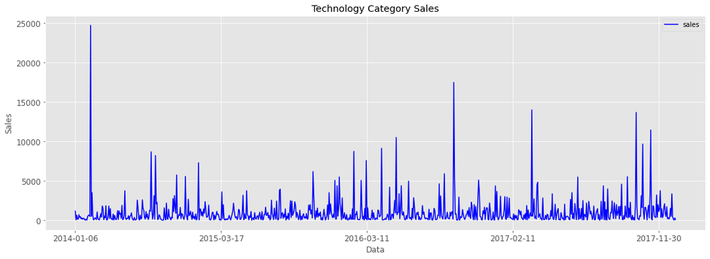

```python
# Plotting sales in the technology category
sales_technology = ts_technology[['sales']]
ax = sales_technology.plot(color = 'b', figsize = (18,6))
plt.xlabel("Data")
plt.ylabel('Sales')
plt.title("Technology Category Sales")
plt.show()
```

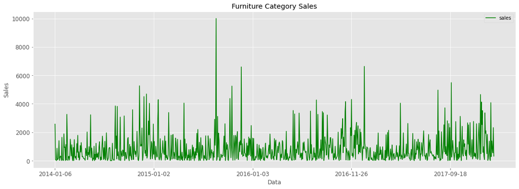

```python
# Plotting sales in the furniture category
sales_furniture = ts_furniture[['sales']]
ax = sales_furniture.plot(color = 'g', figsize = (18,6))
plt.xlabel("Data")
plt.ylabel('Sales')
plt.title("Furniture Category Sales")
plt.show()
```

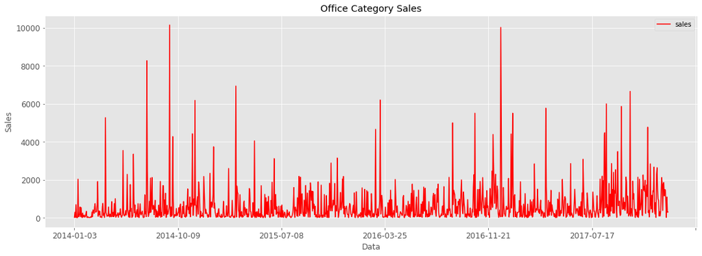

```python
# Plotting sales in the office category
sales_office = ts_office[['sales']]
ax = sales_office.plot(color = 'r', figsize = (18,6))
plt.xlabel("Data")
plt.ylabel('Sales')
plt.title("Office Category Sales")
plt.show()
```

Adjusting the index type to DateTimeIndex (which characterizes a time series), so that it's possible to aggregate monthly and obtain the mean monthly sales.

```python
# Checking index type
type(sales_technology.index)
```

```
pandas.core.indexes.base.Index
```

```python
# Changing index type
sales_technology.index = pd.to_datetime(sales_technology.index)
sales_furniture.index = pd.to_datetime(sales_furniture.index)
sales_office.index = pd.to_datetime(sales_office.index)
```

```python
# Checking index type
type(sales_technology.index)
```

```
pandas.core.indexes.datetimes.DatetimeIndex
```

```python
# Resampling data to a monthly frequency
# Done by setting the month as index and then calculating the mean of daily sales over the month
sales_technology_monthly_mean = sales_technology['sales'].resample('MS').mean()
sales_furniture_monthly_mean = sales_furniture['sales'].resample('MS').mean()
sales_office_monthly_mean = sales_office['sales'].resample('MS').mean()
```

```python
# Verifying the resulting type
type(sales_technology_monthly_mean)
```

```
pandas.core.series.Series
```

```python
# Checking the data
sales_technology_monthly_mean
```

```
order_date
2014-01-01     449.041429
2014-02-01     229.787143
2014-03-01    2031.948375
2014-04-01     613.028933
2014-05-01     564.698588
2014-06-01     766.905909
2014-07-01     533.608933
2014-08-01     708.435385
2014-09-01    2035.838133
2014-10-01     596.900900
2014-11-01    1208.056320
2014-12-01    1160.732889
2015-01-01     925.070800
2015-02-01     431.121250
2015-03-01     574.662333
2015-04-01     697.559500
2015-05-01     831.642857
2015-06-01     429.024400
2015-07-01     691.397733
2015-08-01    1108.902286
2015-09-01     950.856400
2015-10-01     594.716111
2015-11-01    1037.982652
2015-12-01    1619.637636
2016-01-01     374.671067
2016-02-01    1225.891400
2016-03-01    1135.150105
2016-04-01     875.911882
2016-05-01    1601.816167
2016-06-01    1023.259500
2016-07-01     829.312500
2016-08-01     483.620100
2016-09-01    1144.170300
2016-10-01    1970.835875
2016-11-01    1085.642360
2016-12-01     970.554870
2017-01-01    1195.218071
2017-02-01     430.501714
2017-03-01    1392.859250
2017-04-01     825.559133
2017-05-01     678.329400
2017-06-01     853.055000
2017-07-01    1054.996636
2017-08-01     978.842333
2017-09-01    1077.704120
2017-10-01    1493.439227
2017-11-01    1996.750920
2017-12-01     955.865652
Freq: MS, Name: sales, dtype: float64
```

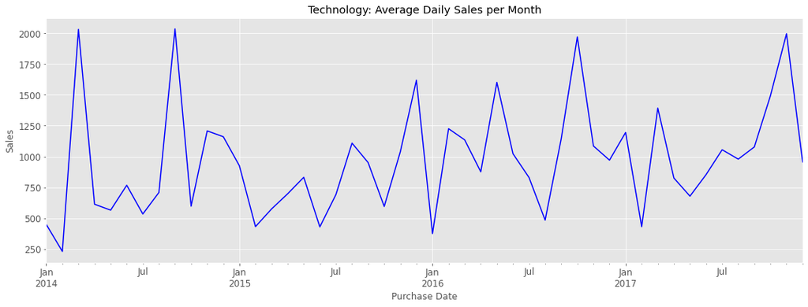

```python
# Plotting the monthly mean daily sales of technology products
sales_technology_monthly_mean.plot(figsize = (18, 6), color = 'blue')
plt.xlabel("Purchase Date")
plt.ylabel('Sales')
plt.title("Technology: Average Daily Sales per Month")
plt.show()
```

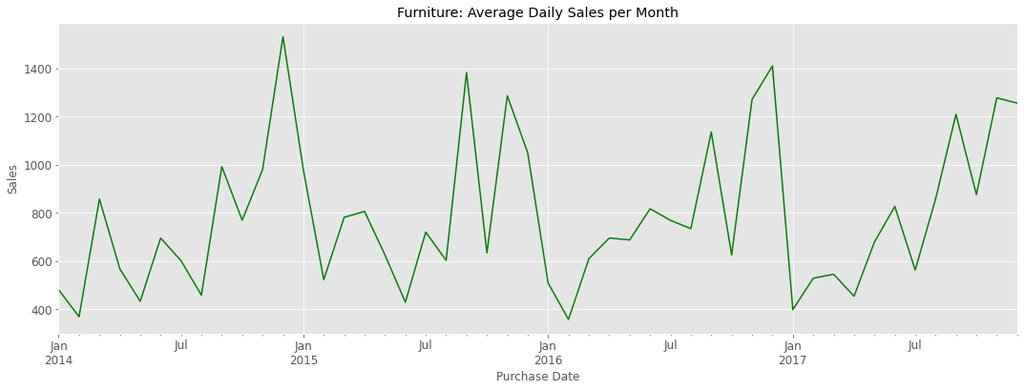

```python
# Plotting the monthly mean daily sales of furniture products
sales_furniture_monthly_mean.plot(figsize = (18, 6), color = 'green')
plt.xlabel("Purchase Date")
plt.ylabel('Sales')
plt.title("Furniture: Average Daily Sales per Month")
plt.show()
```

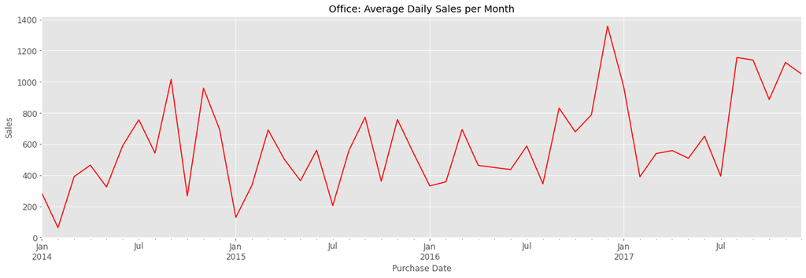

```python
# Plotting the monthly mean daily sales of office products
sales_office_monthly_mean.plot(figsize = (20, 6), color = 'red')
plt.xlabel("Purchase Date")
plt.ylabel('Sales')
plt.title("Office: Average Daily Sales per Month")
plt.show()
```

Decomposing the series to analyze its componentes.

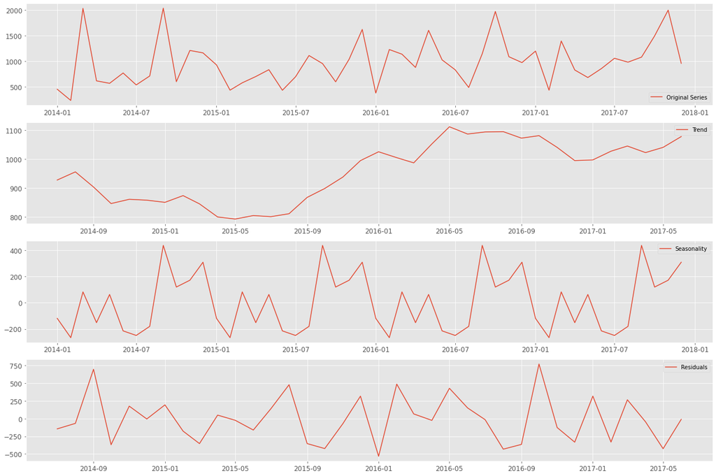

```python
# Decomposing the time series with the monthly mean daily sales of technology products
decomposition = seasonal_decompose(sales_technology_monthly_mean, freq = 12)
rcParams['figure.figsize'] = 18, 12

# Components
trend = decomposition.trend
seasonal = decomposition.seasonal
residual = decomposition.resid

# Plot
plt.subplot(411)
plt.plot(sales_technology_monthly_mean, label = 'Original Series')
plt.legend(loc = 'best')
plt.subplot(412)
plt.plot(trend, label = 'Trend')
plt.legend(loc = 'best')
plt.subplot(413)
plt.plot(seasonal, label = 'Seasonality')
plt.legend(loc = 'best')
plt.subplot(414)
plt.plot(residual, label = 'Residuals')
plt.legend(loc = 'best')
plt.tight_layout()
```

Stationarity test:

```python
# Function to test stationarity
def stationarity_test(serie):

    # Calculating moving statistics
    rolmean = serie.rolling(window = 12).mean()
    rolstd = serie.rolling(window = 12).std()

    # Plot of moving statistics
    orig = plt.plot(serie, color = 'blue', label = 'Original')
    mean = plt.plot(rolmean, color = 'red', label = 'Moving Average')
    std = plt.plot(rolstd, color = 'black', label = 'Standard Deviation')
    plt.legend(loc = 'best')
    plt.title('Moving Statistics - Mean and Standard Deviation')
    plt.show()

    # Dickey-Fuller test:
    # Print
    print('\nDickey-Fuller Test Result:\n')

    # Test
    dftest = adfuller(serie, autolag = 'AIC')

    # Formatting the output
    df_output = pd.Series(dftest[0:4], index = ['Test Statistic',
                                               'P-value',
                                               'Number of Lags Considered',
                                               'Number of Observations Used'])

    # Loop through each item in the test output
    for key, value in dftest[4].items():
        df_output['Critical Value (%s)'%key] = value

    # Print
    print (df_output)

    # Testing p-value
    print ('\nConclusion:')
    if df_output[1] > 0.05:
        print('\nThe p-value is above 0.05, therefore there are no evidences to reject the null hypothesis.')
        print('This series probably is not stationary.')
    else:
        print('\nThe p-value is below 0.05, therefore there are evidences to reject the null hypothesis.')
        print('This series probably is stationary.')
```

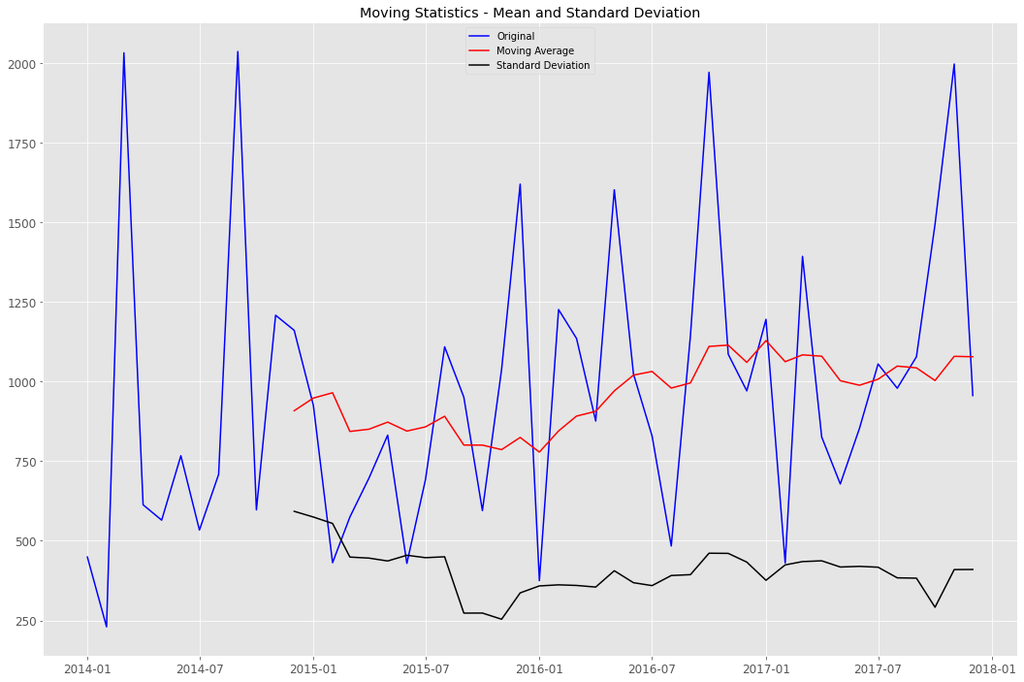

```
Dickey-Fuller Test Result:

Test Statistic                -7.187969e+00
P-value                        2.547334e-10
Number of Lags Considered      0.000000e+00
Number of Observations Used    4.700000e+01
Critical Value (1%)           -3.577848e+00
Critical Value (5%)           -2.925338e+00
Critical Value (10%)          -2.600774e+00
dtype: float64

Conclusion:

The p-value is below 0.05, therefore there are evidences to reject the null hypothesis.
This series probably is stationary.
```

```python
# Verifying if the series is stationary
stationarity_test(sales_technology_monthly_mean)
```

## Train-Test Split

```python
# Original series
X = sales_technology_monthly_mean
```

```python
# Using the first 3 years (first 36 rows) for training
X[:-12]
```

```
order_date
2014-01-01     449.041429
2014-02-01     229.787143
2014-03-01    2031.948375
2014-04-01     613.028933
2014-05-01     564.698588
2014-06-01     766.905909
2014-07-01     533.608933
2014-08-01     708.435385
2014-09-01    2035.838133
2014-10-01     596.900900
2014-11-01    1208.056320
2014-12-01    1160.732889
2015-01-01     925.070800
2015-02-01     431.121250
2015-03-01     574.662333
2015-04-01     697.559500
2015-05-01     831.642857
2015-06-01     429.024400
2015-07-01     691.397733
2015-08-01    1108.902286
2015-09-01     950.856400
2015-10-01     594.716111
2015-11-01    1037.982652
2015-12-01    1619.637636
2016-01-01     374.671067
2016-02-01    1225.891400
2016-03-01    1135.150105
2016-04-01     875.911882
2016-05-01    1601.816167
2016-06-01    1023.259500
2016-07-01     829.312500
2016-08-01     483.620100
2016-09-01    1144.170300
2016-10-01    1970.835875
2016-11-01    1085.642360
2016-12-01     970.554870
Freq: MS, Name: sales, dtype: float64
```

```python
# Using the last year (last 12 rows) for testing
X[-12:]
```

```
order_date
2017-01-01    1195.218071
2017-02-01     430.501714
2017-03-01    1392.859250
2017-04-01     825.559133
2017-05-01     678.329400
2017-06-01     853.055000
2017-07-01    1054.996636
2017-08-01     978.842333
2017-09-01    1077.704120
2017-10-01    1493.439227
2017-11-01    1996.750920
2017-12-01     955.865652
Freq: MS, Name: sales, dtype: float64
```

```python
# Train-test split
training, testing = np.array(X[:-12]), np.array(X[-12:])
```

```python
# Ajusta o shape, pois agora não temos um objeto pd.Series,
# mas sim um array NumPy, que é necessário para treinar o modelo LSTM
trainset = training.reshape(-1,1)
testset = testing.reshape(-1,1)
```

```python
len(trainset)
```

```
36
```

```python
training
```

```
array([ 449.04142857,  229.78714286, 2031.948375  ,  613.02893333,
        564.69858824,  766.90590909,  533.60893333,  708.43538462,
       2035.83813333,  596.9009    , 1208.05632   , 1160.73288889,
        925.0708    ,  431.12125   ,  574.66233333,  697.5595    ,
        831.64285714,  429.0244    ,  691.39773333, 1108.90228571,
        950.8564    ,  594.71611111, 1037.98265217, 1619.63763636,
        374.67106667, 1225.8914    , 1135.15010526,  875.91188235,
       1601.81616667, 1023.2595    ,  829.3125    ,  483.6201    ,
       1144.1703    , 1970.835875  , 1085.64236   ,  970.55486957])
```

```python
trainset
```

```
array([[ 449.04142857],
       [ 229.78714286],
       [2031.948375  ],
       [ 613.02893333],
       [ 564.69858824],
       [ 766.90590909],
       [ 533.60893333],
       [ 708.43538462],
       [2035.83813333],
       [ 596.9009    ],
       [1208.05632   ],
       [1160.73288889],
       [ 925.0708    ],
       [ 431.12125   ],
       [ 574.66233333],
       [ 697.5595    ],
       [ 831.64285714],
       [ 429.0244    ],
       [ 691.39773333],
       [1108.90228571],
       [ 950.8564    ],
       [ 594.71611111],
       [1037.98265217],
       [1619.63763636],
       [ 374.67106667],
       [1225.8914    ],
       [1135.15010526],
       [ 875.91188235],
       [1601.81616667],
       [1023.2595    ],
       [ 829.3125    ],
       [ 483.6201    ],
       [1144.1703    ],
       [1970.835875  ],
       [1085.64236   ],
       [ 970.55486957]])
```

```python
len(testset)
```

```
12
```

```python
testset
```

```
array([[1195.21807143],
       [ 430.50171429],
       [1392.85925   ],
       [ 825.55913333],
       [ 678.3294    ],
       [ 853.055     ],
       [1054.99663636],
       [ 978.84233333],
       [1077.70412   ],
       [1493.43922727],
       [1996.75092   ],
       [ 955.86565217]])
```

## GluonTS

```python
# Function
def plot_forecast(predictor, test_data):
    for test_entry, forecast in zip(test_data, predictor.predict(test_data)):
        to_pandas(test_entry).plot(linewidth = 2)
        forecast.plot(color = 'g', prediction_intervals = [50.0, 90.0])
    plt.grid(which = 'both')
```

**Preparing the Dataset for GluonTS**

GluonTS doesn't require a specific format for the inputed data. The only requiresments are iterable data and having fields named "start" and "target", where "start" represents the first point on the series index (the date), and "target" represents the series values. This is done with the `gluonts.dataset.common.ListDataset` class. Here **start** is `pandas.index` and **target** is an iterable with the values on the sales column.

```python
# Training dataset
training_data = ListDataset([{"start": trainset.index[0],
                              "target": trainset.sales[: "2016-12-01"]}],
                            freq = "M")
```

```python
# Testing dataset
test_data = ListDataset([{"start": testset.index[0],
                           "target": testset.sales[:"2017-12-01"]}],
                        freq = "M")
```

```python
# Creating model
# https://gluon-ts.mxnet.io/api/gluonts/gluonts.model.deepar.html
gluonts_model = DeepAREstimator(freq = "M",
                                 prediction_length = 12,
                                 distr_output = NegativeBinomialOutput(),
                                 num_layers = 2,
                                 trainer = Trainer(learning_rate = 1e-3,
                                                   epochs = 500,
                                                   num_batches_per_epoch = 50,
                                                   batch_size = 32))
```

```
INFO:root:Using CPU
```

```python
# Training model
gluonts_model_predictor = gluonts_model.train(training_data = training_data)
```

```
INFO:root:Start model training
INFO:root:Epoch[0] Learning rate is 0.001
INFO:numexpr.utils:NumExpr defaulting to 8 threads.
INFO:root:Number of parameters in DeepARTrainingNetwork: 36403
```

```
learning rate from ``lr_scheduler`` has been overwritten by ``learning_rate`` in optimizer.
```

[output not shown]

[output cut: 1452 more lines]

```
INFO:root:Epoch[496] Learning rate is 5e-05
INFO:root:Epoch[496] Elapsed time 1.355 seconds
INFO:root:Epoch[496] Evaluation metric 'epoch_loss'=4.356849
INFO:root:Epoch[497] Learning rate is 5e-05
INFO:root:Epoch[497] Elapsed time 1.327 seconds
INFO:root:Epoch[497] Evaluation metric 'epoch_loss'=4.352720
INFO:root:Epoch[498] Learning rate is 5e-05
INFO:root:Epoch[498] Elapsed time 1.310 seconds
INFO:root:Epoch[498] Evaluation metric 'epoch_loss'=4.349209
INFO:root:Epoch[499] Learning rate is 5e-05
INFO:root:Epoch[499] Elapsed time 1.308 seconds
INFO:root:Epoch[499] Evaluation metric 'epoch_loss'=4.347969
INFO:root:Loading parameters from best epoch (499)
INFO:root:Final loss: 4.34796856880188 (occurred at epoch 499)
INFO:root:End model training
```

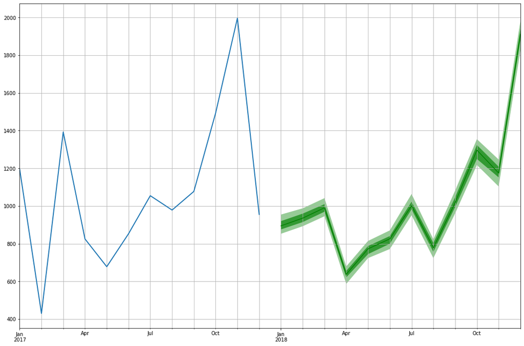

```python
# Plotting prediction
plot_forecast(predictor = gluonts_model_predictor, test_data = test_data)
```

```python
# Predictions with test data
forecast_it, ts_it = make_evaluation_predictions(dataset = test_data,
                                                 predictor = gluonts_model_predictor,
                                                 num_samples = 12)
```

```python
# Extract metrics
aggregate_metrics, item_metrics = Evaluator()(ts_it, forecast_it, num_series = len(test_data))
```

```python
# Visualize metrics
aggregate_metrics
```

```
{'MSE': 1315580.5833333333,
 'abs_error': 12933.12109375,
 'abs_target_sum': 12933.12109375,
 'abs_target_mean': 1077.7600911458333,
 'seasonal_error': nan,
 'MASE': nan,
 'sMAPE': 2.0,
 'MSIS': nan,
 'QuantileLoss[0.1]': 2586.6242797851564,
 'Coverage[0.1]': 0.0,
 'QuantileLoss[0.2]': 5173.248559570313,
 'Coverage[0.2]': 0.0,
 'QuantileLoss[0.3]': 7759.872839355468,
 'Coverage[0.3]': 0.0,
 'QuantileLoss[0.4]': 10346.497119140626,
 'Coverage[0.4]': 0.0,
 'QuantileLoss[0.5]': 12933.121398925781,
 'Coverage[0.5]': 0.0,
 'QuantileLoss[0.6]': 15519.745678710937,
 'Coverage[0.6]': 0.0,
 'QuantileLoss[0.7]': 18106.369958496092,
 'Coverage[0.7]': 0.0,
 'QuantileLoss[0.8]': 20692.99423828125,
 'Coverage[0.8]': 0.0,
 'QuantileLoss[0.9]': 23279.618518066403,
 'Coverage[0.9]': 0.0,
 'RMSE': 1146.987612545721,
 'NRMSE': 1.0642327749641274,
 'ND': 1.0,
 'wQuantileLoss[0.1]': 0.20000000471929058,
 'wQuantileLoss[0.2]': 0.40000000943858116,
 'wQuantileLoss[0.3]': 0.6000000141578716,
 'wQuantileLoss[0.4]': 0.8000000188771623,
 'wQuantileLoss[0.5]': 1.0000000235964528,
 'wQuantileLoss[0.6]': 1.2000000283157433,
 'wQuantileLoss[0.7]': 1.4000000330350337,
 'wQuantileLoss[0.8]': 1.6000000377543246,
 'wQuantileLoss[0.9]': 1.800000042473615,
 'mean_wQuantileLoss': 1.0000000235964528,
 'MAE_Coverage': 0.5}
```

Model comparison:

**ARMA (3,1):**

> - The prediction MSE is 168192.9
> - The prediction RMSE is 410.11
> - The prediction MAPE is 28.4

**ARIMA (6,0,4):**

> - The prediction MSE is 120137.97
> - The prediction RMSE is 346.61
> - The prediction MAPE is 20.1

**SARIMA (0,0,1)x(1,1,0,12):**

> - The prediction MSE is 184433.09
> - The prediction RMSE is 429.46
> - The prediction MAPE is 35.35

**SARIMA (1,1,1)x(1,1,0,12):**

> - The prediction MSE is 229093.55
> - The prediction RMSE is 478.64
> - The prediction MAPE is 47.48

**SARIMAX (1,1,1)x(1,1,0,12):**

> - The prediction MSE is 231232.42
> - The prediction RMSE is 480.87
> - The prediction MAPE is 47.99

**Prophet:**

> - The prediction MSE is 105965.29
> - The prediction RMSE is 325.52
> - The prediction MAPE is 26.45

**Stacked LSTM:**

> - The prediction MSE is 155874.09
> - The prediction RMSE is 394.81
> - The prediction MAPE is 35.56

**Differentiated LSTM:**

> - The prediction MSE is 377007.27
> - The prediction RMSE is 614.01
> - The prediction MAPE is 57.85

**Bidirectional LSTM:**

> - The prediction MSE is 132553.55
> - The prediction RMSE is 364.08
> - The prediction MAPE is 25.86

## Part 6: https://drive.google.com/open?id=16UGQmZQ930c68MGlXynJ0DzFZFbH1L75